# 1.離散型データ事例

## 1.7ベイジアンネットワークの図示

詳細は以下に記載あり

https://www.bnlearn.com/examples/graphviz-plot/

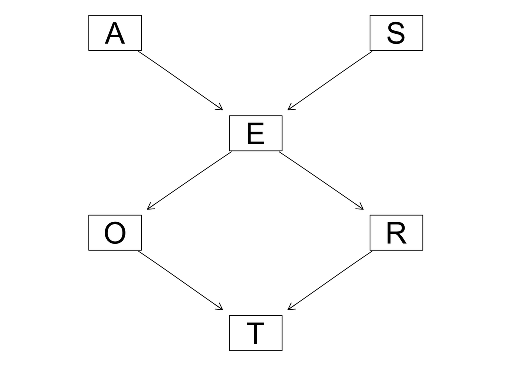

```r
graphviz.plot(dag)
```

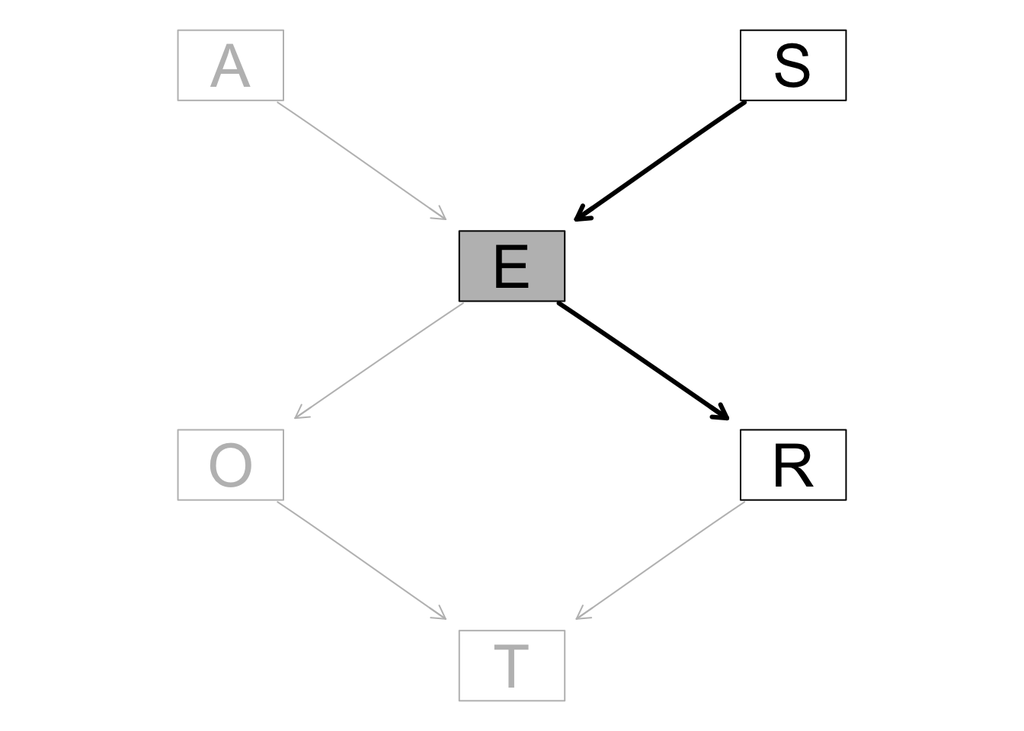

```r
hlight <- list(nodes = nodes(dag), arcs = arcs(dag), col = "grey", textCol = "grey")
pp <- graphviz.plot(dag, highlight = hlight, render = FALSE)

library(Rgraphviz)
edgeRenderInfo(pp) <- list(col = c("S~E" ="black", "E~R" = "black"),
                           lwd = c("S~E" = 3, "E~R" = 3))
nodeRenderInfo(pp) <-
  list(col = c("S" = "black", "E" = "black", "R" = "black"),
       textCol = c("S" = "black", "E" = "black", "R" = "black"),
       fill = c("E" = "grey"))
renderGraph(pp)
```

### 1.7.2条件付き確率分布の図示

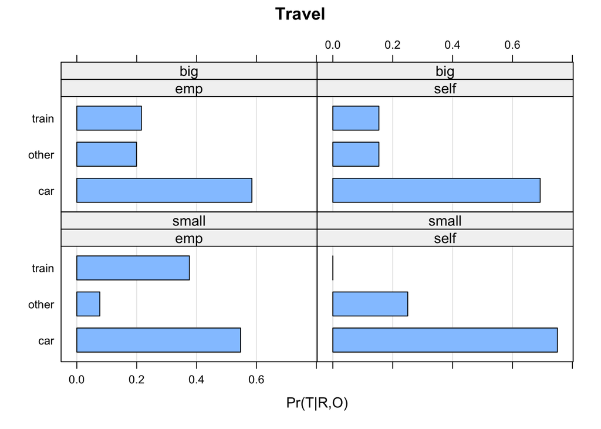

```r
bn.fit.barchart(bn.mle$T, main = "Travel", xlab = "Pr(T|R,O)", ylab ="")
```

交通手段の周辺確率と2つの条件付き確率クエリの結果を比較する

```r
Evidence <- factor(c(rep("Unconditional",3), rep("Female", 3),
                     rep("Small City",3)),
              levels = c("Unconditional", "Female", "Small City"))
Travel <- factor(rep(c("car", "train", "other"), 3),
            levels = c("other", "train", "car"))
distr <- data.frame(Evidence = Evidence, Travel = Travel,
           Prob = c(0.5618, 0.2808, 0.15730, 0.5620, 0.2806,
                    0.1573, 0.4838, 0.4170, 0.0990))
distr
```

| Evidence | Travel | Prob |
| --- | --- | --- |
| Unconditional | car | 0.5618 |
| Unconditional | train | 0.2808 |
| Unconditional | other | 0.1573 |
| Female | car | 0.5620 |
| Female | train | 0.2806 |
| Female | other | 0.1573 |
| Small City | car | 0.4838 |
| Small City | train | 0.4170 |
| Small City | other | 0.0990 |

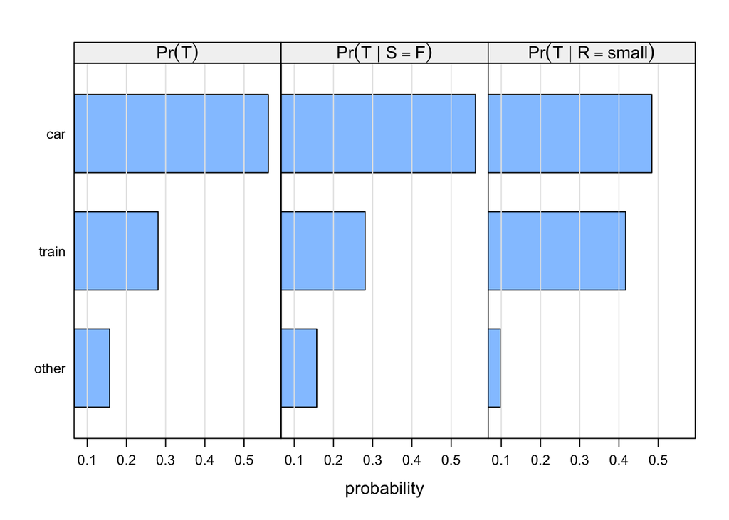

```r
library(lattice)
barchart(Travel ~ Prob | Evidence, data = distr,
   layout = c(3, 1), xlab = "probability",
   scales = list(alternating = 1, tck = c(1, 0)),
   strip = strip.custom(factor.levels =
     c(expression(Pr(T)),
       expression(Pr({T} * " | " * {S == F})),
       expression(Pr({T} * " | " * {R == small})))),
   panel = function(...) {
     panel.barchart(...)
     panel.grid(h = 0, v = -1)
   })
```

仕様書

https://www.bnlearn.com/documentation/man/graphviz.chart.html

このあたりはグラフ描画がうまくいかないのでパス。そこまで重要でもないし

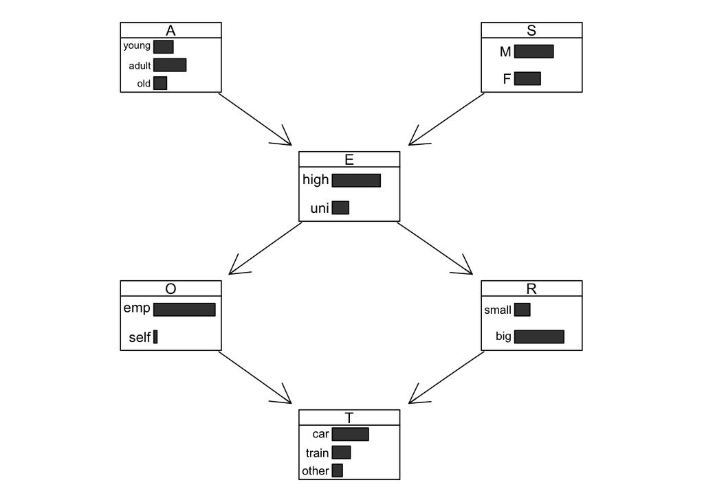

```r
library("Rgraphviz")
graphviz.chart(bn)
```

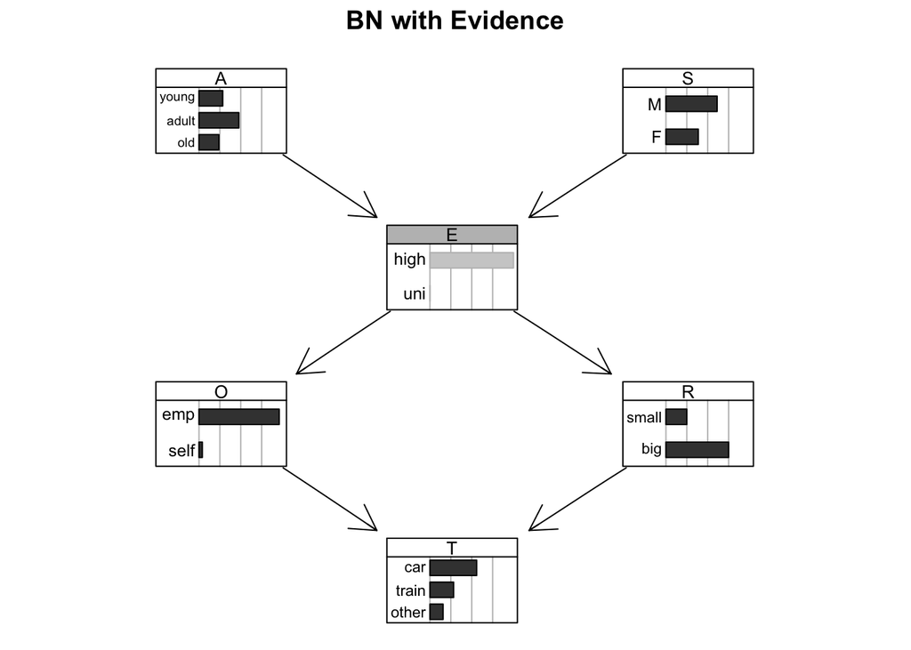

```r
graphviz.chart(as.bn.fit(jedu, including.evidence = TRUE), grid = TRUE,
    bar.col = c(A = "black", S = "black", E = "grey", O = "black",
                R = "black", T = "black"),
    strip.bg = c(A = "transparent", S = "transparent", E = "grey",
                 O = "transparent", R = "transparent", T = "transparent"),
    main = "BN with Evidence")
```

# 2.連続型データ事例：ガウシアン・ベイジアンネットワーク

## 2.1事例紹介

- 遺伝的ポテンシャル：genetic potential;G
- 環境的ポテンシャル：environmental potential;E
- 種子の数;N
- 種子の平均重量;W
- 栄養器官：単一の植物に蓄えられる栄養に関する情報すべてを統合した変数;V
- 目的変数：作物の収穫量;C

それぞれを1つの連続型変数として扱う

## 2.2グラフィカル表現

```r
library(bnlearn)
dag.bnlearn <- model2network("[G][E][V|G:E][N|V][W|V][C|N:W]")
dag.bnlearn
```

```
##
##   Random/Generated Bayesian network
##
##   model:
##    [E][G][V|E:G][N|V][W|V][C|N:W]
##   nodes:                                 6
##   arcs:                                  6
##     undirected arcs:                     0
##     directed arcs:                       6
##   average markov blanket size:           2.67
##   average neighbourhood size:            2.00
##   average branching factor:              1.00
##
##   generation algorithm:                  Empty
```

```r
graphviz.plot(dag.bnlearn)
```

[output not shown]

```r
#どの変数の組み合わせが周辺的に独立しているか確認する
crop.nodes <- nodes(dag.bnlearn)
for(n1 in crop.nodes){
  for(n2 in crop.nodes){
    if(dsep(dag.bnlearn, n1, n2))
       cat(n1, "and", n2, "are independent.\n")
  }
}
```

```
## E and G are independent.
## G and E are independent.
```

EとGのみが独立している、独立性は対称的だった

```r
#変数をすべての組あわせで対にして、栄養器官(V)で条件づけられた場合にどのペアが条件付き独立となるか確認できる
for(n1 in crop.nodes[crop.nodes != "V"]){
  for(n2 in crop.nodes[crop.nodes != "V"]){
   if(n1<n2){
     if(dsep(dag.bnlearn, n1, n2, "V"))
       cat(n1, "and", n2, "are independent given V.\n")
   }
  }
}
```

```
## C and E are independent given V.
## C and G are independent given V.
## E and N are independent given V.
## E and W are independent given V.
## G and N are independent given V.
## G and W are independent given V.
## N and W are independent given V.
```

Vで条件づけられるとEとGは独立ではない

## 2.3確率的表現

```r
#各パラメータの確率分布を定義する
E.dist <- list(coef = c("(Intercept)" = 50), sd = 10)
G.dist <- list(coef = c("(Intercept)" = 50), sd = 10)
V.dist <- list(coef = c("(Intercept)" = -10.35534, E = 0.70711, G = 0.5), sd = 5)
N.dist <- list(coef = c("(Intercept)" = 45, V = 0.1), sd = 9.949874)
W.dist <- list(coef = c("(Intercept)" = 15, V = 0.7), sd = 7.141428)
C.dist <- list(coef = c("(Intercept)" = 0, N = 0.3, W = 0.7), sd = 6.25)
dist.list <- list(E = E.dist, G = G.dist, V = V.dist, N = N.dist, W = W.dist, C = C.dist)
```

```r
gbn.bnlearn <- custom.fit(dag.bnlearn, dist = dist.list)
```

```r
#局所分布のパラメータ
gbn.bnlearn$C
```

```
##
##   Parameters of node C (Gaussian distribution)
##
## Conditional density: C | N + W
## Coefficients:
## (Intercept)            N            W
##         0.0          0.3          0.7
## Standard deviation of the residuals: 6.25
```

上記は線形ガウシアン・ベイジアンネットワークである

- すべてのノードは正規分布に基づく
- 親のノードをもたないノードは周辺分布により記述
- 各ノードの分散はそのノードに特有で親ノードに依存しない
- 各ノードの局所的分布は切片と親ノードを含んだ線形ガウシアンモデルとして表現

```r
#ガウシアン・ベイジアンネットワークに特化したRパッケージ
library(rbmn)
#bn.fitオブジェクトを変換する
gbn.rbmn <- bnfit2nbn(gbn.bnlearn)
```

```r
#多変量正規分布のパラメータを得る
gema.rbmn <- nbn2gema(gbn.rbmn)
mn.rbmn <- gema2mn(gema.rbmn)
print8mn(mn.rbmn)
```

```
##   mu s.d.   C.E  C.G   C.V   C.W   C.N   C.C
## E 50   10 1.000 0.00 0.707 0.495 0.071 0.368
## G 50   10 0.000 1.00 0.500 0.350 0.050 0.260
## V 50   10 0.707 0.50 1.000 0.700 0.100 0.520
## W 50   10 0.495 0.35 0.700 1.000 0.070 0.721
## N 50   10 0.071 0.05 0.100 0.070 1.000 0.349
## C 50   10 0.368 0.26 0.520 0.721 0.349 1.000
```

1列目：周辺分布の期待値

2列目：周辺分布の標準偏差

3列目以降：相関行列

## 2.4パラメータの推定：相関係数

DAG構造は既知とする

```r
#200の観測サンプルを生成して、cropdata200に格納する
set.seed(4567)
cropdata200 <- rbn(gbn.bnlearn, n = 200)
set.seed(1234)
cropdata20k <- rbn(gbn.bnlearn, n = 20000)
dim(cropdata200)
```

```
## [1] 200   6
```

```r
round(head(cropdata200), 2)
```

| C | E | G | N | V | W |
| --- | --- | --- | --- | --- | --- |
| 48.83 | 51.48 | 42.64 | 54.10 | 42.96 | 41.96 |
| 48.85 | 73.43 | 40.97 | 60.07 | 65.29 | 48.96 |
| 67.01 | 71.10 | 52.52 | 51.64 | 63.22 | 62.03 |
| 37.83 | 49.33 | 56.15 | 49.01 | 47.75 | 38.77 |
| 55.30 | 49.27 | 63.55 | 54.62 | 60.57 | 56.66 |
| 56.12 | 48.72 | 66.02 | 43.95 | 55.54 | 52.39 |

```r
#パラメータを推定する
#変数が因子型でなければ自動的にガウシアン・ベイジアンネットワークと判断される
crop.fitted <- bn.fit(dag.bnlearn, data = cropdata200)
crop.fitted
```

```
##
##   Bayesian network parameters
##
##   Parameters of node C (Gaussian distribution)
##
## Conditional density: C | N + W
## Coefficients:
## (Intercept)            N            W
##   2.4026177    0.2734476    0.6858202
## Standard deviation of the residuals: 6.31327
##
##   Parameters of node E (Gaussian distribution)
##
## Conditional density: E
## Coefficients:
## (Intercept)
##    50.80161
## Standard deviation of the residuals: 10.7432
##
##   Parameters of node G (Gaussian distribution)
##
## Conditional density: G
## Coefficients:
## (Intercept)
##    50.14396
## Standard deviation of the residuals: 9.798923
##
##   Parameters of node N (Gaussian distribution)
##
## Conditional density: N | V
## Coefficients:
## (Intercept)            V
## 51.81745022  -0.04461524
## Standard deviation of the residuals: 9.531253
##
##   Parameters of node V (Gaussian distribution)
##
## Conditional density: V | E + G
## Coefficients:
## (Intercept)            E            G
## -10.4547647    0.7426946    0.4552872
## Standard deviation of the residuals: 5.034309
##
##   Parameters of node W (Gaussian distribution)
##
## Conditional density: W | V
## Coefficients:
## (Intercept)            V
##  20.1555287    0.5899971
## Standard deviation of the residuals: 6.792171
```

```r
#特定のノードについて異なるパラメータ推定法を用いることもできる
crop.fitted$C <- lm(C ~ N + W, data = cropdata200)
crop.fitted$C
```

```
##
##   Parameters of node C (Gaussian distribution)
##
## Conditional density: C | N + W
## Coefficients:
## (Intercept)            N            W
##   2.4026177    0.2734476    0.6858202
## Standard deviation of the residuals: 6.31327
```

一般的な回帰モデルをもちいてパラメータ推定を行う

リッジ、ラッソ回帰などについては以下を参照

https://aizine.ai/ridge-lasso-elasticnet/

```r
#収穫量Cについてリッジ回帰を当てはめてみる
library(penalized)
crop.fitted$C <- penalized(C ~ N + W, lambda1 = 0, lambda2 = 1.5, data = cropdata200)
```

```
## 12
```

推定した値を真値（avg:50, sd:10)と比較する

```r
crop.fitted$E
```

```
##
##   Parameters of node E (Gaussian distribution)
##
## Conditional density: E
## Coefficients:
## (Intercept)
##    50.80161
## Standard deviation of the residuals: 10.7432
```

```r
crop.fitted$C
```

```
##
##   Parameters of node C (Gaussian distribution)
##
## Conditional density: C | N + W
## Coefficients:
## (Intercept)            N            W
##   2.4069159    0.2734233    0.6857580
## Standard deviation of the residuals: 6.31327
```

NやW、SDについては真値に近似しているが、切片が0とは遠いので以下で直接修正する

```r
crop.fitted$C <- lm(C ~ N + W - 1, data = cropdata200)
crop.fitted$C
```

```
##
##   Parameters of node C (Gaussian distribution)
##
## Conditional density: C | N + W
## Coefficients:
## (Intercept)            N            W
##   0.0000000    0.2963220    0.7105197
## Standard deviation of the residuals: 6.304969
```

## 2.5DAG構造の学習：検定とスコア

### 2.5.1条件付き独立性検定

```r
cormat <- cor(cropdata200[, c("C", "W", "N")])
cormat
```

```
##           C           W           N
## C 1.0000000  0.67479818  0.26480613
## W 0.6747982  1.00000000 -0.02597999
## N 0.2648061 -0.02597999  1.00000000
```

```r
#cormat（相関行列）からinvcor(偏相関行列)を計算する
#ほかのすべての変数で条件づけられた場合のXとYにおける偏相関という意味
library(corpcor)
invcor <- cor2pcor(cormat)
dimnames(invcor) <- dimnames(cormat)
invcor
```

```
##           C          W          N
## C 1.0000000  0.7071522  0.3826989
## W 0.7071522  1.0000000 -0.2875974
## N 0.3826989 -0.2875974  1.0000000
```

```r
#種子の数Nで条件づけられた場合に作物の収穫量Cと種子の平均重量Wは独立か、という仮説を検証できる
ci.test("C", "W", "N", test = "cor", data = cropdata200)
```

```
##
##  Pearson's Correlation
##
## data:  C ~ W | N
## cor = 0.70715, df = 197, p-value < 2.2e-16
## alternative hypothesis: true value is not equal to 0
```

有意な偏相関があったことから帰無仮説を棄却し、独立でないと言える

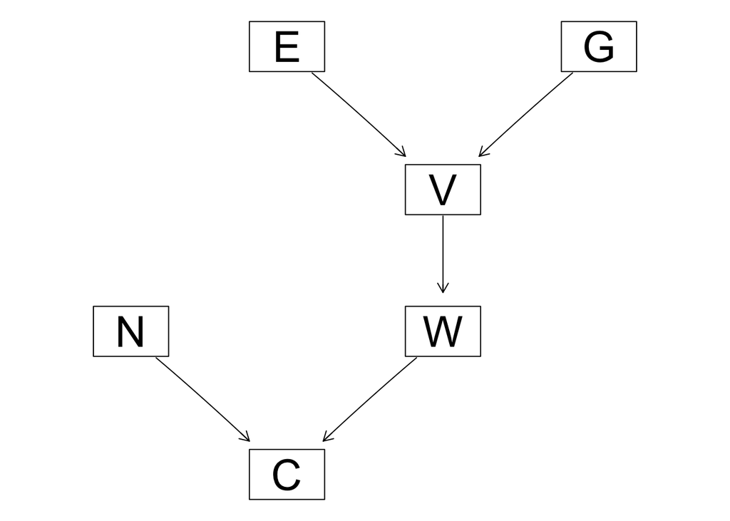

```r
#200個のデータセットは大規模ではないので構造自体を学習させると以下のようになる
pdag1 <- iamb(cropdata200, test = "cor")
graphviz.plot(pdag1)
```

```r
#20kのデータセットを用いると正しく予測できる
pdag2 <- iamb(cropdata20k, test = "cor")
graphviz.plot(pdag2)
```

[output not shown]

```r
#一部アークの追加、削除ができる
wl <- matrix(c("V", "N"), ncol = 2)
pdag3 <- iamb(cropdata200, test = "cor", whitelist = wl)
graphviz.plot(pdag3)
```

[output not shown]

### 2.5.2ネットワークスコア

$$BIC = \log\widehat{f}(E,G,V,N,W,C) - \frac{d}{2}\log n$$

また事後確率のスコアとしてBGe(Bayesian Gaussian equivalent score)

```r
score(dag.bnlearn, data = cropdata20k, type = "bic-g")
```

```
## [1] -416421.2
```

```r
score(dag.bnlearn, data = cropdata20k, type = "bge")
```

```
## [1] -416494.5
```

## 2.6ガウシアン・ベイジアンネットワークを使ってみよう

### 2.6.1厳密推論

```r
print8nbn(gbn.rbmn)
```

```
## =====Nodes===[parents]   = Exp. (sd.dev)
## -----------------------------------------------
## ---------E---[-]  = 50  (10)
## ---------G---[-]  = 50  (10)
## ---------V---[E,G]  = -10.355 + 0.707*E + 0.5*G  (5)
## ---------W---[V]  = 15 + 0.7*V  (7.141)
## ---------N---[V]  = 45 + 0.1*V  (9.95)
## ---------C---[N,W]  = 0.3*N + 0.7*W  (6.25)
```

```r
print8gema(gema.rbmn)
```

```
##   mu     E1   E2  E3    E4    E5   E6
## E 50 10.000  0.0 0.0 0.000 0.000 0.00
## G 50  0.000 10.0 0.0 0.000 0.000 0.00
## V 50  7.071  5.0 5.0 0.000 0.000 0.00
## W 50  4.950  3.5 3.5 7.141 0.000 0.00
## N 50  0.707  0.5 0.5 0.000 9.950 0.00
## C 50  3.677  2.6 2.6 4.999 2.985 6.25
```

別のノードの値を固定した場合の1つor複数のノードの条件付同時分布を算出可能

```r
#Vを80に固定した場合のCの分布
print8mn(condi4joint(mn.rbmn, par = "C", pour = "V", x2 = 80))
```

```
##     mu  s.d.
## C 65.6 8.542
```

### 2.6.2近似推論

### シミュレーションを用いる

- 直接的：rnb関数
- 制約的：cpquery/cpdist関数

```r
#(V,N)から観測値4つを生成する
nobs <- 4
sim <- rbn(gbn.bnlearn, n = nobs)
sim
```

| C | E | G | N | V | W |
| --- | --- | --- | --- | --- | --- |
| 65.41210 | 79.12004 | 67.14710 | 63.82861 | 79.28153 | 59.53187 |
| 46.01587 | 35.57628 | 59.05068 | 51.74454 | 37.51262 | 40.01539 |
| 63.36558 | 62.26097 | 48.24989 | 53.12280 | 57.59524 | 64.20510 |
| 40.36104 | 35.87449 | 59.02320 | 37.77818 | 50.75239 | 47.35855 |

```r
#条件を付けて生成する
#非常に良質な作物を生産するための種子の数や平均重量はどのようなものか
cpdist(gbn.bnlearn, nodes = c("C", "N", "W"), evidence = (C > 80))
```

| C | N | W |
| --- | --- | --- |
| 82.73325 | 66.14010 | 73.51469 |
| 81.32917 | 66.46854 | 80.87893 |
| 83.71564 | 64.03459 | 75.02483 |
| 81.56583 | 55.56495 | 63.87066 |
| 81.67702 | 65.23859 | 65.27324 |
| 80.12171 | 59.03308 | 72.62500 |
| 84.46455 | 62.45442 | 68.80120 |
| 82.76554 | 55.95147 | 71.92902 |
| 85.34518 | 67.96205 | 77.49656 |
| 81.56415 | 44.48874 | 76.90340 |
| 82.04864 | 71.42499 | 81.17855 |
| 80.33468 | 52.22056 | 74.36922 |
| 82.70572 | 56.82981 | 59.85769 |

“=”を使って単一値を条件づける場合はこのアプローチは不可能となる

連続型分布において単一値はつねに確率がゼロであるから

```r
head(cpdist(gbn.bnlearn, nodes = c("V","G","E"), evidence = list(G = 10, E = 90), method = "lw"), n = 5)
```

| V | G | E |
| --- | --- | --- |
| 63.71504 | 10 | 90 |
| 62.78473 | 10 | 90 |
| 67.95987 | 10 | 90 |
| 53.36817 | 10 | 90 |
| 58.42986 | 10 | 90 |

尤度重み付け法を用いることで解決することができる

```r
#特定のイベントに関する確率を算出できる
cpquery(gbn.bnlearn, event = (V > 70), evidence = list(G = 10, E = 90), method = "lw")
```

```
## [1] 0.009666667
```

## 2.7ガウシアン・ベイジアンネットワークの図示

### 2.7.1DAGの図示

```r
library(igraph)
igraph.options(print.full = TRUE)
dag0.igraph <- graph.formula(G-+V, E-+V, V-+N, V-+W, N-+C, W-+C)
dag0.igraph
```

```
## IGRAPH cb0428d DN-- 6 6 --
## + attr: name (v/c)
## + edges from cb0428d (vertex names):
## [1] G->V V->N V->W E->V N->C W->C
```

```r
#bnから変換もできる
dag.igraph <- as.igraph(dag.bnlearn)
```

```r
#ノードを表す
V(dag.igraph)
```

```
## + 6/6 vertices, named, from b1304dd:
## [1] C E G N V W
```

```r
#エッジを表す
E(dag.igraph)
```

```
## + 6/6 edges from b1304dd (vertex names):
## [1] G->V E->V V->N V->W N->C W->C
```

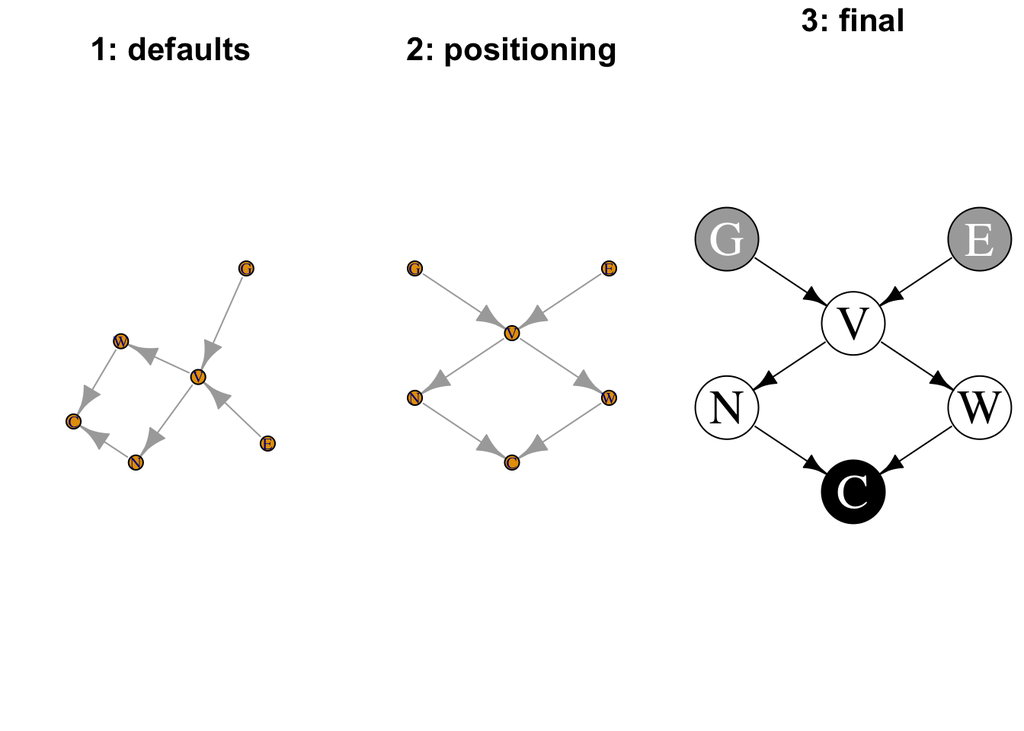

```r
par(mfrow = c(1, 3), mar = rep(3, 4), cex.main = 2)
plot(dag.igraph, main = "\n1: defaults")
ly <- matrix(c(2, 3, 1, 1, 2, 3, 1, 4, 4, 2, 3, 2), 6)
plot(dag.igraph, layout = ly, main = "\n2: positioning")
vcol <- c("black", "darkgrey", "darkgrey", rep(NA, 3))
lcol <- c(rep("white", 3), rep(NA, 3))
par(mar = rep(0, 4), lwd = 1.5)
plot(dag.igraph, layout = ly, frame = TRUE, main = "\n3: final",
     vertex.color = vcol, vertex.label.color = lcol,
     vertex.label.cex = 3, vertex.size = 50,
     edge.arrow.size = 0.8, edge.color = "black")
```

### 2.7.2条件付き確率分布の図示

ガウシアン・ベイジアンネットワークの局所的分布を図示するための関数はない

線形回帰モデルのための回帰診断図を利用することは可能

ただし、残差と当てはめ値がbn.fitオブジェクトに格納されている必要がある

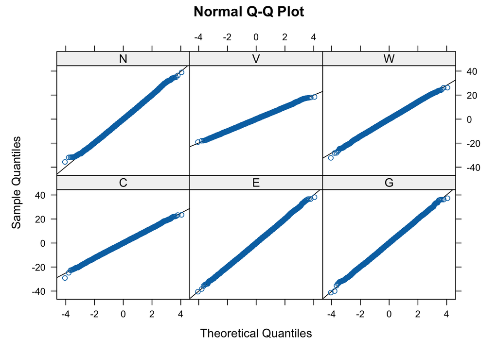

```r
gbn.fit <- bn.fit(dag.bnlearn, data = cropdata20k)
#残差に関するquantile-quantileプロット
bn.fit.qqplot(gbn.fit)
```

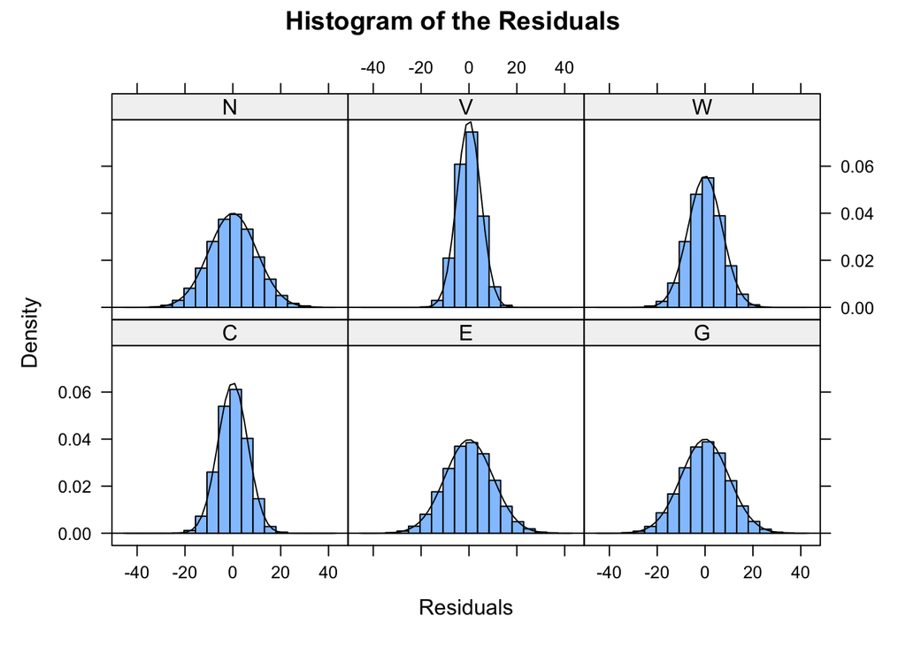

```r
#理論上の正規密度分布と重ねた残差のヒストグラム
bn.fit.histogram(gbn.fit)
```

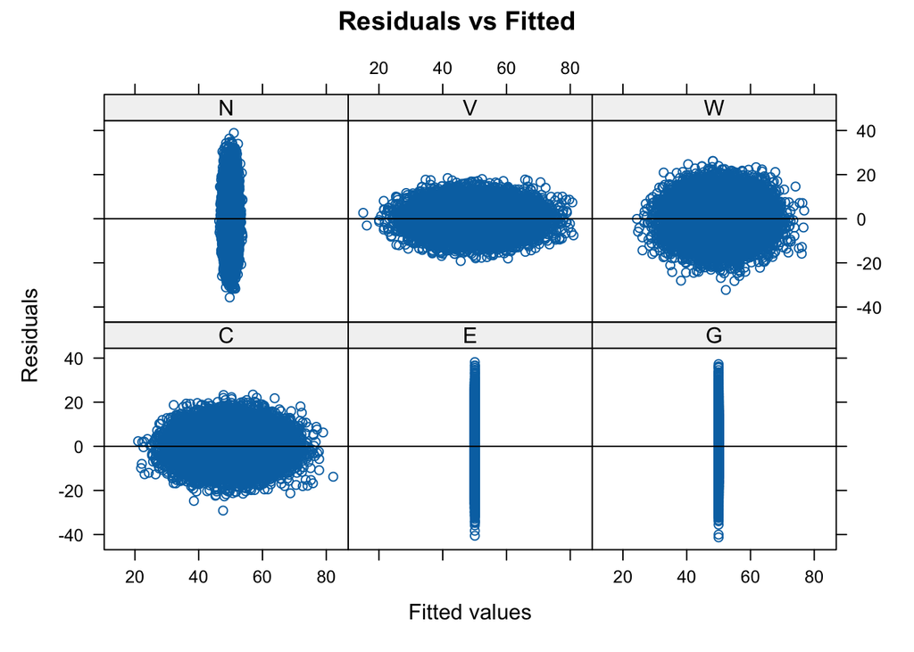

```r
#当てはめ値に対する残差プロット
bn.fit.xyplot(gbn.fit)
```

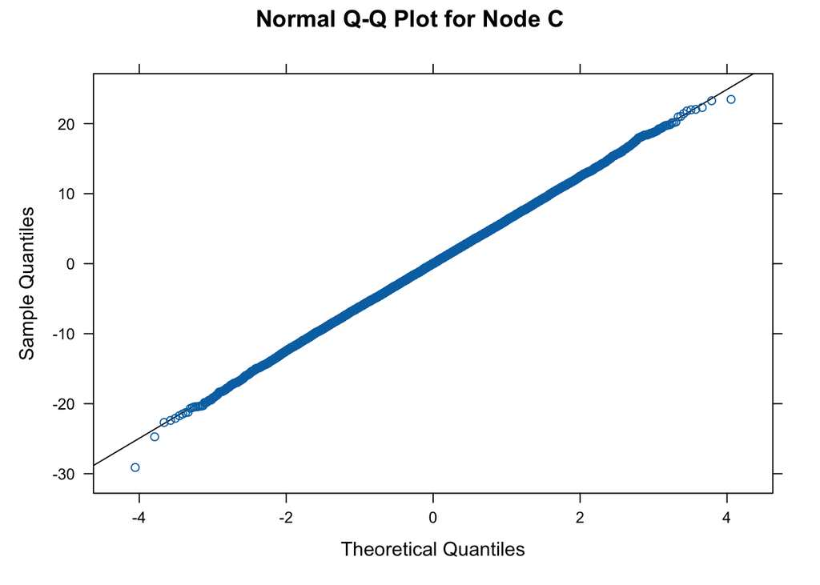

```r
#一つのノードのみに着目した図もかける
bn.fit.qqplot(gbn.fit$C)
```

環境的ポテンシャルEと栄養期間Vの組み合わせに対してどのように収穫量Cが変化するのかについて興味があるとする（C|E,V)

```r
C.EV <- condi4joint(mn.rbmn, par = "C", pour = c("E", "V"), x2 = NULL)
C.EV$rho
```

```
##              E    V
## C 9.665421e-17 0.52
```

Vに関する情報が得られたときはEに関する回帰係数が0になる→Cを推定するに当たりEに関する情報は役に立たない

```r
#VがEとCと有効分離の関係にある
dsep(gbn.bnlearn, "E","C","V")
```

```
## [1] TRUE
```

EとVの両方を変化させた場合のCに関する分布を算出したい

3次元プロットは難しくエラーが発生しやすいので、二次元で観測値のポイントの大きさを変えることで表現する

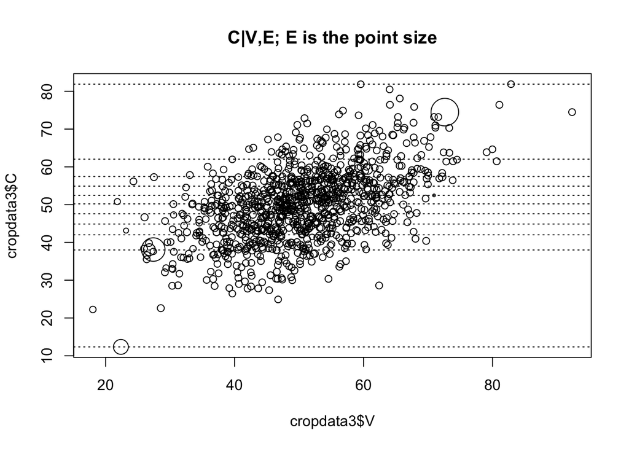

```r
set.seed(5678)
cropdata3 <- cpdist(gbn.bnlearn, nodes = c("E", "V", "C"),
                    evidence = TRUE, n = 1000)
plot(cropdata3$V, cropdata3$C, type = "n", main = "C|V,E; E is the point size")
cexlim <- c(0.1, 2.4)
cexE <- cexlim[1] + diff(cexlim) / diff(range(cropdata3$E) *
                                          (cropdata3$E - min(cropdata3$E)))
points(cropdata3$V, cropdata3$C, cex = cexE*10)
cqa <- quantile(cropdata3$C, seq(0, 1, 0.1))
abline(h = cqa, lty = 3)
```

# 3.混合事例：条件付きガウシアン・ベイジアンネットワーク

## 3.1事例紹介：健康管理にかかるコスト

- Age:A; 離散型
- Pre-existing conditions:C; 離散型：既往歴
- Outpatient expenditure:O; 連続型：通院にかかる費用
- Inpatient expenditure:I;連続型：入院にかかる支出
- Any hospital stay:H;離散型：入院該当の有無
- Days of hospital stay:D; 連続型：入院日数
- Taxes:T;連続型：医療費にかかる税金

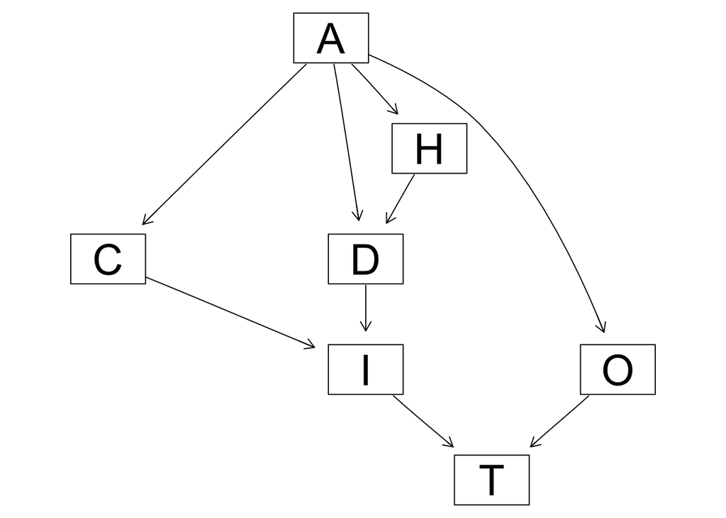

```r
dag <- model2network("[A][C|A][H|A][D|A:H][I|C:D][O|A][T|O:I]")
graphviz.plot(dag)
```

```r
#Aの条件付き確率表作成
A.lv <- c("young", "adult", "old")
A.prob <- array(c(0.35, 0.45, 0.20), dim = 3, dimnames = list(A = A.lv))
A.prob
```

```
## A
## young adult   old
##  0.35  0.45  0.20
```

年齢に応じて既往症のレベルが異なるようにCを条件付ける

```r
C.lv <- c("none", "mild", "severe")
C.prob <- array(c(0.88, 0.10, 0.02, 0.75, 0.20, 0.05, 0.42, 0.53, 0.05),
                dim = c(3, 3), dimnames = list(C = C.lv, A = A.lv))
C.prob
```

```
##         A
## C        young adult  old
##   none    0.88  0.75 0.42
##   mild    0.10  0.20 0.53
##   severe  0.02  0.05 0.05
```

```r
H.lv <- c("none", "any")
H.prob <- array(c(0.90, 0.10, 0.75, 0.25, 0.60, 0.40),
                dim = c(2, 3), dimnames = list(H = H.lv, A = A.lv))
H.prob
```

```
##       A
## H      young adult old
##   none   0.9  0.75 0.6
##   any    0.1  0.25 0.4
```

```r
D.coef <- list(coef = array(c(0, 0, 0, 1, 4, 7), dim = c(1, 6),
                            dimnames = list("(Intercept)", NULL)),
               sd = c(0, 0, 0, 0.5, 1, 1.5))
D.coef
```

```
## $coef
##             [,1] [,2] [,3] [,4] [,5] [,6]
## (Intercept)    0    0    0    1    4    7
##
## $sd
## [1] 0.0 0.0 0.0 0.5 1.0 1.5
```

DはH(入院の有無)×A(young mild old)に対応している

Hがnoneなら0

- 離散型変数→連続型変数の場合
  - 親ノードの離散型変数の値に応じて複数の線形回帰モデルをセットとして表現する
- 連続型変数が複数の離散型変数を親ノードとして持つ場合
  - 親ノードの値に対応した回帰モデルを複数含む形で構成される
- 連続型変数の親ノードが連続型変数である場合
  - 親ノードの連続型変数が子ノードの下位モデルに混在する形

```r
I.coef <- list(coef = array(c(1, 3, 1, 5.5, 1, 8) * 100 ,
                            dim = c(2, 3), dimnames = list(c("(Intercept)", "D"), NULL)) ,
               sd = c(30, 50, 100))
I.coef
```

```
## $coef
##             [,1] [,2] [,3]
## (Intercept)  100  100  100
## D            300  550  800
##
## $sd
## [1]  30  50 100
```

```r
O.coef <- list(coef = array(c(60, 180, 360), dim = c(1, 3),
                            dimnames = list("(Intercept)", NULL)),
               sd = c(10, 20, 40))
T.coef <- list(coef = c("(Intercept)" = 120, I = 1.02, O = 1.05),
               sd = 10)
```

$$T= 120+1.02I+1.05O+\varepsilon_T\sim N(0,10^2)$$

上記内容でBNを定義したのでbn.fitオブジェクトを作成する

```r
dists <- list(A = A.prob, C= C.prob, H = H.prob, D= D.coef,
              I = I.coef, O = O.coef, "T" = T.coef)
healthcare <- custom.fit(dag, dists)
healthcare$I
```

```
##
##   Parameters of node I (conditional Gaussian distribution)
##
## Conditional density: I | C + D
## Coefficients:
##                0    1    2
## (Intercept)  100  100  100
## D            300  550  800
## Standard deviation of the residuals:
##   0    1    2
##  30   50  100
## Discrete parents' configurations:
##         C
## 0    none
## 1    mild
## 2  severe
```

上記で構築したものが、条件付きガウシアン・ベイジアンネットワーク（CGBN）である。

- 離散型ノードは多項分布に従う
- 連続型ノード（親ノードに離散型を含まない）は正規分布に従う
- 1つ以上の離散型ノードの親を持つ連続型ノードは、離散型変数である親の状態を組み合わせた中における1つの要素の混合正規分布に従う
- 混合状態における各要素は独立したパラメータを持つ
- 連続型ノードは連続型ノード、離散型ノードいずれも親にできる  
  離散型ノードは離散型ノードしか親にできない

## 3.3パラメータの推定：混合回帰

すでにDAGは既知であるとする

```r
costs <- read.table("data/healthcare.txt", header = TRUE,
                    colClasses = c("factor", "factor", "numeric", "factor",
                                   "numeric", "numeric", "numeric"))
```

```r
#最尤推定法で局所的分布のパラメータを推定した
fitted <- bn.fit(dag, data = costs)
```

```r
#今回推定したもの
coef(fitted$H)
```

```
##       A
## H          adult       old     young
##   any  0.2380435 0.4239401 0.1060383
##   none 0.7619565 0.5760599 0.8939617
```

```r
#経験的頻度を用いて推定したもの→つまり実際の値から算出される確率
cpt.H <- prop.table(table(costs[, c("H", "A")]), margin = 2)
#これをfitの推定値と比較してみる
all.equal(cpt.H, coef(fitted$H))
```

```
## [1] TRUE
```

同じものが得られている